# Funding Futures: Exploring K-12 Education Finance Equity with R

A Guided Notebook Using the `edfinr` Package and the C2C Student Pathways Dashboard

Lesson Plan Challenge — Introduction to Education Policy & Data Science

2026-03-15

**Welcome to this guided notebook!** You will use real U.S. school district finance data to explore a central question in education equity:

> *Does where you grow up — and how much money your school district has — shape your path to college and career?*

This notebook is scaffolded into three parts. Read every section, run the code, and answer the reflection questions as you go. There are no wrong answers — just careful thinking.

# 1 Part A: Getting Started with `edfinr`

## 1.1 What is `edfinr`?

The `edfinr` package gives you access to a powerful, tidy dataset combining three major federal data sources for every K-12 school district in the United States (school years 2011–12 through 2021–22):

| Source | What it measures |
| --- | --- |
| **NCES F-33 Survey** | How each district raises money (local, state, federal revenue) and spends it (instruction, support, administration) |
| **Census SAIPE** | Poverty rate estimates at the school-district level |
| **ACS 5-Year Estimates** | Community demographics: income, educational attainment, and more |

By combining these, `edfinr` lets us ask: *How does a community’s poverty level connect to the resources its schools receive?*

## 1.2 Install and Load Packages

Run this chunk first. If you’re using **Posit Cloud**, these packages may already be available. If you’re on your own computer, the install lines will download them.

```r
# Uncomment these lines if you need to install packages
# install.packages("edfinr")
# install.packages("tidyverse")
# install.packages("scales")
# install.packages("ggrepel")
# install.packages("skimr")

library(edfinr)
library(tidyverse)
library(scales)
library(ggrepel)
library(skimr)

# Set a clean ggplot theme for all our visualizations
theme_set(
  theme_minimal(base_size = 13) +
    theme(
      plot.title    = element_text(color = "#005F73", face = "bold", size = 15),
      plot.subtitle = element_text(color = "#444444", size = 12),
      axis.title    = element_text(color = "#333333"),
      strip.text    = element_text(face = "bold", color = "#005F73"),
      panel.grid.minor = element_blank()
    )
)
```

## 1.3 Explore Available Geographies

Before downloading data, let’s see what states are available.

```r
# View all available state codes
states <- get_states()
print(states)
```

```
##  [1] "AL" "AK" "AZ" "AR" "CA" "CO" "CT" "DE" "FL" "GA" "HI" "ID" "IL" "IN" "IA"
## [16] "KS" "KY" "LA" "ME" "MD" "MA" "MI" "MN" "MS" "MO" "MT" "NE" "NV" "NH" "NJ"
## [31] "NM" "NY" "NC" "ND" "OH" "OK" "OR" "PA" "RI" "SC" "SD" "TN" "TX" "UT" "VT"
## [46] "VA" "WA" "WV" "WI" "WY" "DC"
```

**What do you notice?** The data covers all 50 states plus D.C. We’ll focus on California to connect our analysis to the **C2C Student Pathways Dashboard**, which covers California K-12 districts.

## 1.4 Download California Finance Data

```r
# Download California school district data for 2021-22
# The 'skinny' dataset has 41 key variables — just right for exploration
ca_data <- get_finance_data(
  yr           = "2022",
  geo          = "CA",
  dataset_type = "skinny"
)

# Take a first look
skim(ca_data)
```

Data summary

| Name | ca_data |
| --- | --- |
| Number of rows | 1860 |
| Number of columns | 41 |
| _______________________ |  |
| Column type frequency: |  |
| character | 8 |
| factor | 2 |
| numeric | 31 |
| ________________________ |  |
| Group variables | None |

**Variable type: character**

| skim_variable | n_missing | complete_rate | min | max | empty | n_unique | whitespace |
| --- | --- | --- | --- | --- | --- | --- | --- |
| ncesid | 0 | 1 | 7 | 7 | 0 | 1860 | 0 |
| year | 0 | 1 | 4 | 4 | 0 | 1 | 0 |
| state | 0 | 1 | 2 | 2 | 0 | 1 | 0 |
| dist_name | 0 | 1 | 6 | 60 | 0 | 1847 | 0 |
| state_leaid | 0 | 1 | 10 | 10 | 0 | 1860 | 0 |
| county | 0 | 1 | 11 | 22 | 0 | 58 | 0 |
| cbsa | 0 | 1 | 1 | 5 | 0 | 35 | 0 |
| schlev | 0 | 1 | 2 | 2 | 0 | 3 | 0 |

**Variable type: factor**

| skim_variable | n_missing | complete_rate | ordered | n_unique | top_counts |
| --- | --- | --- | --- | --- | --- |
| urbanicity | 0 | 1 | FALSE | 4 | Cit: 661, Sub: 601, Rur: 399, Tow: 199 |
| lea_type | 0 | 1 | FALSE | 3 | Ind: 941, Reg: 914, Sup: 5, Reg: 0 |

**Variable type: numeric**

| skim_variable | n_missing | complete_rate | mean | sd | p0 | p25 | p50 | p75 | p100 | hist |
| --- | --- | --- | --- | --- | --- | --- | --- | --- | --- | --- |
| enroll | 0 | 1.00 | 3136.07 | 12142.91 | 6.00 | 262.00 | 514.00 | 2117.75 | 4.359580e+05 | ▇▁▁▁▁ |
| rev_total_pp | 0 | 1.00 | 18364.81 | 6940.94 | 7466.67 | 14547.58 | 17076.13 | 19888.34 | 7.252459e+04 | ▇▂▁▁▁ |
| rev_local_pp | 0 | 1.00 | 6415.74 | 6043.89 | 125.25 | 3131.96 | 4571.60 | 7494.91 | 5.582143e+04 | ▇▁▁▁▁ |
| rev_state_pp | 0 | 1.00 | 9697.33 | 4019.73 | 651.36 | 7334.44 | 9676.61 | 11713.75 | 4.371552e+04 | ▇▇▁▁▁ |
| rev_fed_pp | 0 | 1.00 | 2251.74 | 1840.80 | 0.00 | 1144.72 | 1925.15 | 2860.12 | 2.852398e+04 | ▇▁▁▁▁ |
| rev_total | 0 | 1.00 | 61380174.19 | 316237370.22 | 280000.00 | 4318250.00 | 8343500.00 | 38108500.00 | 1.228880e+10 | ▇▁▁▁▁ |
| rev_local | 0 | 1.00 | 21198979.17 | 96686514.53 | 16276.95 | 954398.09 | 2325860.34 | 11681000.00 | 3.295337e+09 | ▇▁▁▁▁ |
| rev_state | 0 | 1.00 | 32291222.67 | 169125616.83 | 86829.27 | 2153500.00 | 4697500.00 | 17651278.88 | 6.594600e+09 | ▇▁▁▁▁ |
| rev_fed | 0 | 1.00 | 7889972.35 | 58943795.43 | 0.00 | 386337.62 | 999000.00 | 3792954.65 | 2.398866e+09 | ▇▁▁▁▁ |
| rev_total_unadj | 0 | 1.00 | 63152583.33 | 322150671.73 | 287000.00 | 4365000.00 | 8515500.00 | 38297000.00 | 1.251286e+10 | ▇▁▁▁▁ |
| rev_local_unadj | 0 | 1.00 | 21548376.34 | 97010736.21 | 18000.00 | 971750.00 | 2362500.00 | 11969250.00 | 3.296792e+09 | ▇▁▁▁▁ |
| rev_state_unadj | 0 | 1.00 | 33581137.10 | 174724510.23 | 89000.00 | 2199750.00 | 4897500.00 | 18223500.00 | 6.816142e+09 | ▇▁▁▁▁ |
| rev_fed_unadj | 0 | 1.00 | 8023069.89 | 59055964.43 | 0.00 | 399500.00 | 1011500.00 | 3867000.00 | 2.399925e+09 | ▇▁▁▁▁ |
| exp_cur_pp | 0 | 1.00 | 15684.24 | 5274.24 | 6650.00 | 12782.96 | 14795.10 | 17001.44 | 6.303571e+04 | ▇▂▁▁▁ |
| rev_exp_pp_diff | 0 | 1.00 | 2680.57 | 3090.69 | -11263.16 | 963.45 | 2136.36 | 3729.58 | 3.728509e+04 | ▁▇▁▁▁ |
| exp_cur_st_loc | 0 | 1.00 | 41957824.19 | 183455333.82 | 171000.00 | 3557000.00 | 6694500.00 | 27558750.00 | 6.896420e+09 | ▇▁▁▁▁ |
| exp_cur_fed | 0 | 1.00 | 7256805.91 | 55868809.43 | 0.00 | 0.00 | 661000.00 | 3479250.00 | 2.268233e+09 | ▇▁▁▁▁ |
| exp_cur_resa | 0 | 1.00 | 0.00 | 0.00 | 0.00 | 0.00 | 0.00 | 0.00 | 0.000000e+00 | ▁▁▇▁▁ |
| exp_cur_total | 0 | 1.00 | 49214630.11 | 238114540.04 | 186000.00 | 3832250.00 | 7392500.00 | 31056500.00 | 9.164653e+09 | ▇▁▁▁▁ |
| cpi_sy12 | 0 | 1.00 | 1.24 | 0.00 | 1.24 | 1.24 | 1.24 | 1.24 | 1.240000e+00 | ▁▁▇▁▁ |
| mhi | 953 | 0.49 | 90889.62 | 40409.12 | 25918.00 | 62925.50 | 82618.00 | 108750.00 | 2.500010e+05 | ▆▇▂▁▁ |
| mpv | 954 | 0.49 | 628160.52 | 436064.55 | 9999.00 | 322250.00 | 490950.00 | 764875.00 | 2.000001e+06 | ▇▇▂▁▁ |
| adult_pop | 947 | 0.49 | 36266.20 | 121987.37 | 27.00 | 2022.00 | 10705.00 | 38047.00 | 3.230775e+06 | ▇▁▁▁▁ |
| ba_plus_pop | 947 | 0.49 | 12906.73 | 45207.35 | 0.00 | 425.00 | 2381.00 | 11957.00 | 1.111665e+06 | ▇▁▁▁▁ |
| ba_plus_pct | 947 | 0.49 | 0.30 | 0.19 | 0.00 | 0.16 | 0.25 | 0.40 | 8.600000e-01 | ▆▇▅▂▁ |
| total_pop | 947 | 0.49 | 53469.55 | 171430.62 | 69.00 | 2772.00 | 15936.00 | 57574.00 | 4.509398e+06 | ▇▁▁▁▁ |
| student_pop | 947 | 0.49 | 6900.27 | 24120.72 | 9.00 | 341.00 | 2139.00 | 6830.00 | 6.543120e+05 | ▇▁▁▁▁ |
| stpov_pop | 947 | 0.49 | 1001.70 | 4872.77 | 1.00 | 47.00 | 222.00 | 805.00 | 1.370730e+05 | ▇▁▁▁▁ |
| stpov_pct | 947 | 0.49 | 0.16 | 0.09 | 0.01 | 0.09 | 0.14 | 0.21 | 6.700000e-01 | ▇▆▁▁▁ |
| cong_dist | 0 | 1.00 | 622.06 | 16.25 | 601.00 | 607.00 | 621.00 | 635.00 | 6.530000e+02 | ▇▅▅▃▃ |
| lea_type_id | 0 | 1.00 | 4.04 | 3.00 | 1.00 | 1.00 | 7.00 | 7.00 | 7.000000e+00 | ▇▁▁▁▇ |

## 1.5 Explore Key Variables

The dataset contains many variables. Let’s focus on the most important ones for equity analysis.

```r
# Select and examine key variables
ca_key <- ca_data |>
  select(
    # Identifiers
    ncesid, dist_name, lea_type,
    # Geography
    urbanicity,
    # Enrollment
    enroll,
    # Revenue (per pupil)
    rev_total_pp,     # Total revenue per pupil
    rev_local_pp,     # Local revenue per pupil (mostly property taxes)
    rev_state_pp,     # State aid per pupil
    rev_fed_pp,       # Federal revenue per pupil
    # Expenditures
    exp_cur_pp,   # Current expenditures per pupil
    # Demographics
    stpov_pct,   # % students in poverty (SAIPE)
    # CPI adjustment index (not present here since cpi_adj='none' by default)
  ) |>
  filter(!is.na(rev_total_pp), !is.na(stpov_pct), enroll > 0)

# Summary statistics
summary(ca_key[, c("rev_total_pp", "rev_local_pp", "rev_state_pp", "stpov_pct", "enroll")])
```

```
##   rev_total_pp    rev_local_pp    rev_state_pp     stpov_pct
##  Min.   :11934   Min.   :  725   Min.   : 2034   Min.   :0.01256
##  1st Qu.:16568   1st Qu.: 3915   1st Qu.: 7250   1st Qu.:0.08724
##  Median :18880   Median : 6070   Median :10011   Median :0.14085
##  Mean   :21181   Mean   : 8575   Mean   :10051   Mean   :0.15702
##  3rd Qu.:22480   3rd Qu.: 9741   3rd Qu.:12587   3rd Qu.:0.20625
##  Max.   :72525   Max.   :55821   Max.   :32375   Max.   :0.67391
##      enroll
##  Min.   :     6
##  1st Qu.:   344
##  Median :  1753
##  Mean   :  5745
##  3rd Qu.:  5936
##  Max.   :435958
```

[figure not shown]

```r
# Visualized
ca_key[, c("rev_total_pp", "rev_local_pp", "rev_state_pp", "stpov_pct", "enroll")] |>
  pivot_longer(cols = everything()) |>
  mutate(name = case_when(
    name == 'enroll' ~ "Enrollment",
    name == 'rev_local_pp' ~ "Local\nPer-Pupil\nExpenditure",
    name == 'rev_state_pp' ~ "State\nPer-Pupil\nExpenditure",
    name == 'rev_total_pp' ~ "Total\nPer-Pupil\nExpenditure",
    name == 'stpov_pct' ~ "% Students\nin Poverty"
  )) |>
  ggplot(aes(x = name,
             y = value)) +
  geom_boxplot(fill = "#005F73") +
  facet_wrap(~name, scales = 'free', ncol = 5) +
  theme(axis.text.x = element_blank()) +
  labs(x = 'variable',
       title = "Summary of Key Variables",
       caption  = "Source: edfinr")
```

**Checkpoint A.1 — Reflection:**

- What is the range of total per-pupil revenue across California districts? What does the gap between the minimum and maximum tell you?
- What is the median poverty rate? How does that compare to what you expected?

*Write 2–3 sentences below (use a `#` comment):*

```r
# YOUR ANSWER HERE:
#
```

# 2 Part B: Equity Visualizations

## 2.1 The Core Question: Does Poverty Predict Funding?

In theory, the U.S. education funding system should direct more money to districts with greater need. In practice, because local property taxes are a major funding source, districts with low property values (which correlate with poverty) often receive less money.

Let’s see what the data shows.

[figure not shown]

```r
# Scatter plot: poverty rate vs. per-pupil revenue, colored by district locale

ggplot(ca_key,
       aes(x = stpov_pct,
           y = rev_total_pp,
           color = urbanicity,
           size = enroll)) +
  geom_point(alpha = 0.55) +
  geom_smooth(aes(group = 1),
              # aes(color = urbanicity),
              method = "lm",
              se = TRUE,
              color = "red4",
              linewidth = 1.2,
              linetype = "dashed",
              fill = "#D4ECF0") +
  scale_y_continuous(labels = dollar_format(scale = 1)) +
  scale_x_continuous(labels = percent_format(scale = 1)) +
  scale_size_continuous(range = c(1, 8),
                        labels = comma) +
  scale_color_manual(values = c(City = "#005F73",
                                Suburb = "#0A9396",
                                Town = "#94D2BD",
                                Rural = "#EE9B00",
                                Other = "#888888")) +
  labs(
    title    = "Per-Pupil Revenue vs. Student Poverty Rate, California Districts (2021-22)",
    subtitle = "Each point is one school district. Size reflects enrollment. Darker points indicate more urbanicity.",
    x        = "Percentage of Students in Poverty",
    y        = "Total Revenue Per Pupil (USD)",
    color    = "District Locale",
    size     = "Enrollment",
    caption  = "Source: edfinr | NCES F-33 + Census SAIPE"
  ) +
  theme(legend.position = "right")
```

**Checkpoint B.1 — Discussion:**

Look carefully at the scatter plot and the trend line.

1. Does higher poverty **predict more or less** per-pupil revenue? Does the trend line slope upward or downward?
2. Are there districts that seem to “break the pattern”? Where are they located (urban/rural/suburban)?
3. What might explain districts with **high poverty AND high revenue**? (Hint: think about federal Title I funding)

*Answer in comments below:*

```r
# YOUR ANSWER HERE:
# 1.
# 2.
# 3.
```

## 2.2 Revenue Sources: Who Funds Whom?

Let’s break down revenue by source to understand the story better.

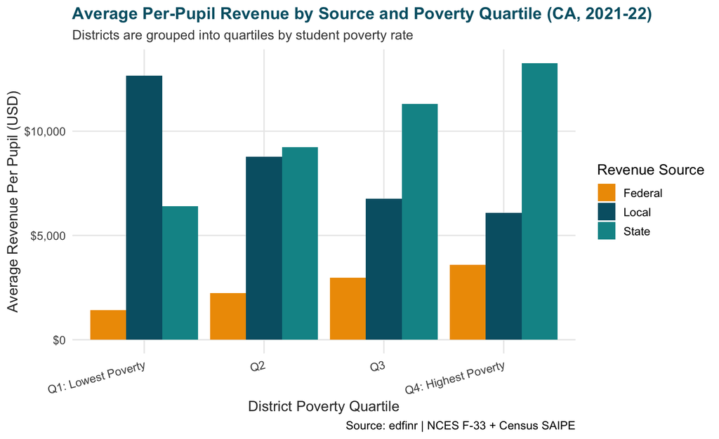

```r
# Categorize districts into poverty quartiles
ca_key <- ca_key |>
  mutate(
    poverty_quartile = ntile(stpov_pct, 4),
    poverty_label = case_when(
      poverty_quartile == 1 ~ "Q1: Lowest Poverty",
      poverty_quartile == 2 ~ "Q2",
      poverty_quartile == 3 ~ "Q3",
      poverty_quartile == 4 ~ "Q4: Highest Poverty"
    )
  )

# Average revenue by source and poverty quartile
revenue_summary <- ca_key |>
  group_by(poverty_label) |>
  summarize(
    Local   = mean(rev_local_pp, na.rm = TRUE),
    State   = mean(rev_state_pp, na.rm = TRUE),
    Federal = mean(rev_fed_pp,   na.rm = TRUE),
    .groups = "drop"
  ) |>
  pivot_longer(cols = c(Local, State, Federal),
               names_to = "Source",
               values_to = "Revenue_PP")

ggplot(revenue_summary,
       aes(x = poverty_label,
           y = Revenue_PP, fill = Source)) +
  geom_col(position = "dodge") +
  scale_y_continuous(labels = dollar_format(scale = 1)) +
  scale_fill_manual(values = c(Local = "#005F73",
                               State = "#0A9396",
                               Federal = "#EE9B00")) +
  labs(
    title    = "Average Per-Pupil Revenue by Source and Poverty Quartile (CA, 2021-22)",
    subtitle = "Districts are grouped into quartiles by student poverty rate",
    x        = "District Poverty Quartile",
    y        = "Average Revenue Per Pupil (USD)",
    fill     = "Revenue Source",
    caption  = "Source: edfinr | NCES F-33 + Census SAIPE"
  ) +
  theme(axis.text.x = element_text(angle = 15, hjust = 1))
```

**What to look for:** - **Local revenue** should be higher for low-poverty districts (wealthy property tax base). - **Federal revenue** should be higher for high-poverty districts (Title I targeting). - **State revenue** should partially compensate — but does it fully close the gap?

**Checkpoint B.2 — Reflection:**

After viewing the grouped bar chart:

1. Does local revenue follow the pattern you expected (higher in low-poverty districts)?
2. Does federal revenue compensate adequately? Does it fully close the gap?
3. What would a **truly equitable** funding system look like? Describe it in 2 sentences.

```r
# YOUR ANSWER HERE:
# 1.
# 2.
# 3.
```

## 2.3 Multi-Year Trend: How Has Funding Changed Over Time?

Let’s load multiple years of data to see trends. We’ll use CPI adjustment to compare dollars fairly across years.

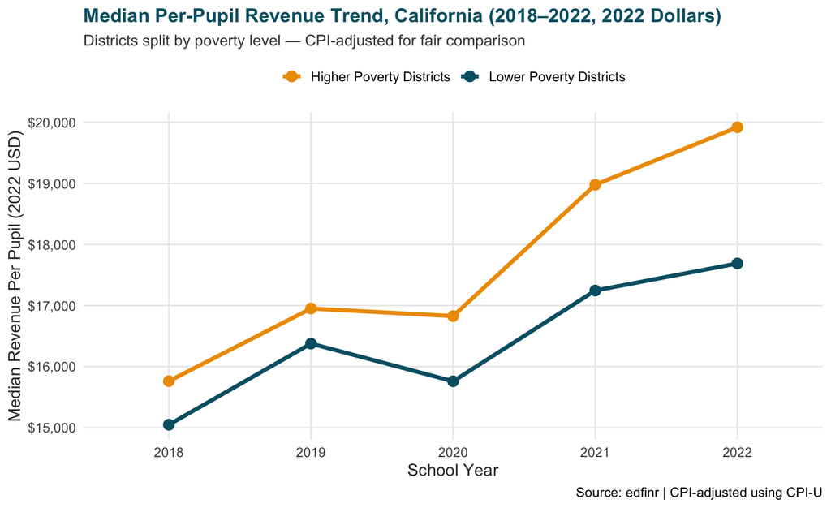

```r
# Download 5 years of California data, adjusted to 2022 dollars
ca_multi <- get_finance_data(
  yr           = "2018:2022",
  geo          = "CA",
  dataset_type = "skinny",
  cpi_adj      = "2022"   # All values in 2021-22 dollars
)

# Annual median per-pupil revenue, split by high vs. low poverty
ca_trend <- ca_multi |>
  filter(!is.na(rev_total_pp),
         !is.na(stpov_pct),
         enroll > 0) |>
  mutate(
    high_poverty = ifelse(stpov_pct >= median(stpov_pct, na.rm = TRUE),
                          "Higher Poverty Districts",
                          "Lower Poverty Districts")
  ) |>
  group_by(year, high_poverty) |>
  summarize(median_rev_pp = median(rev_total_pp,
                                   na.rm = TRUE),
            .groups = "drop")

ggplot(ca_trend,
       aes(x = year,
           y = median_rev_pp,
           color = high_poverty,
           group = high_poverty)) +
  geom_line(linewidth = 1.5) +
  geom_point(size = 3.5) +
  scale_y_continuous(labels = dollar_format(scale = 1)) +
  scale_color_manual(values = c("Higher Poverty Districts" = "#EE9B00",
                                "Lower Poverty Districts"  = "#005F73")) +
  labs(
    title    = "Median Per-Pupil Revenue Trend, California (2018–2022, 2022 Dollars)",
    subtitle = "Districts split by poverty level — CPI-adjusted for fair comparison",
    x        = "School Year",
    y        = "Median Revenue Per Pupil (2022 USD)",
    color    = NULL,
    caption  = "Source: edfinr | CPI-adjusted using CPI-U"
  ) +
  theme(legend.position = "top")
```

## 2.4 (Optional) Compare Two States

Now let’s compare California with another state (potential your home state) to see structural differences.

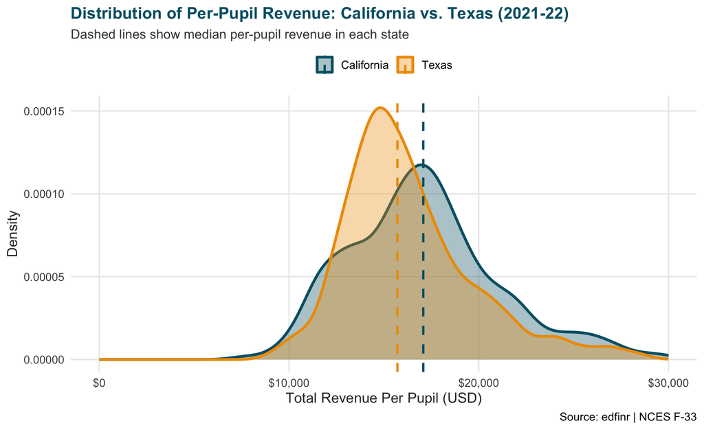

```r
# Download data for California and Texas
regional <- get_finance_data(
  yr           = "2022",
  geo          = "CA,TX",
  dataset_type = "skinny"
)

# Density plot of per-pupil revenue distributions
regional_clean <- regional |>
  filter(!is.na(rev_total_pp), enroll > 0) |>
  mutate(state = ifelse(str_detect(ncesid, "^06"),
                        "California",
                        "Texas"))

ggplot(regional_clean,
       aes(x = rev_total_pp,
           fill = state,
           color = state)) +
  geom_density(alpha = 0.35,
               linewidth = 1.2) +
  geom_vline(data = regional_clean |>
               group_by(state) |>
               summarize(med = median(rev_total_pp, na.rm=TRUE)),
             aes(xintercept = med, color = state),
             linetype = "dashed", linewidth = 1) +
  scale_x_continuous(labels = dollar_format(scale = 1),
                     limits = c(0, 30000)) +
  scale_fill_manual(values  = c(California = "#005F73",
                                Texas = "#EE9B00")) +
  scale_color_manual(values = c(California = "#005F73",
                                Texas = "#EE9B00")) +
  labs(
    title    = "Distribution of Per-Pupil Revenue: California vs. Texas (2021-22)",
    subtitle = "Dashed lines show median per-pupil revenue in each state",
    x        = "Total Revenue Per Pupil (USD)",
    y        = "Density",
    fill     = NULL, color = NULL,
    caption  = "Source: edfinr | NCES F-33"
  ) +
  theme(legend.position = "top")
```

**Checkpoint B.3 — Comparison:**

1. Which state has a wider distribution of per-pupil revenue? What does a wider distribution suggest about **equity within** that state?
2. Does one state’s median funding significantly differ from the other’s?
3. Which state would you predict has more equitable student outcomes on the C2C dashboard, and why?

```r
# YOUR ANSWER HERE:
# 1.
# 2.
# 3.
```

# 3 Part C: Connecting to the C2C Student Pathways Dashboard

## 3.1 Bridge: From Finance Data to Student Outcomes

The `edfinr` data tells us about **inputs** (money going into the system). The **C2C Student Pathways Dashboard** shows us **outputs** (student outcomes like graduation rates and college enrollment).

Now we connect the two.

**Action: Open the C2C Dashboard**

Go to: [**https://databydesign.caschooldashboard.org/**](https://databydesign.caschooldashboard.org/)

1. Navigate to any California school district
2. Apply the **“Socioeconomically Disadvantaged”** filter under student groups
3. Compare outcomes to non-disadvantaged peers
4. Click the **“How do I read this chart?”** pop-out box and read the explanation
5. Click any ⓘ **information circle** for variable definitions
6. Look for any **blank or greyed-out** data cells — these are **suppressed data points**

## 3.2 Understanding Data Suppression

The C2C dashboard hides data for student groups with **10 or fewer individuals**. This is the **Cradle-to-Career System Data Suppression Protocol**.

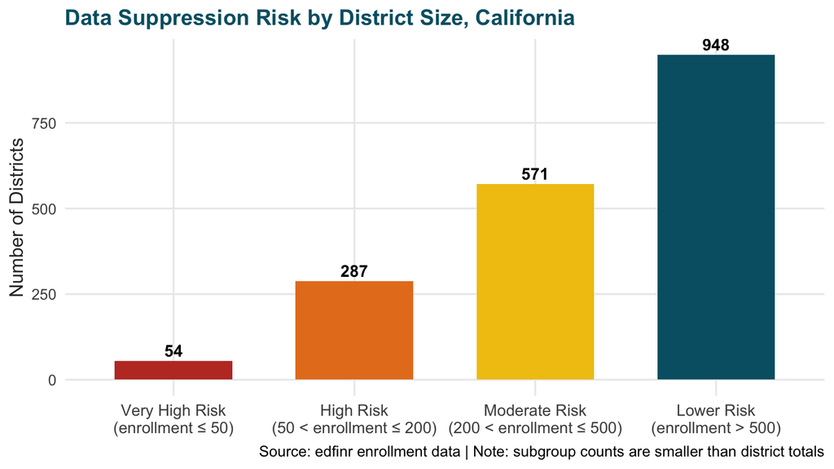

```r
# Illustrate data suppression conceptually:
# How many California districts have small enrollment in a given subgroup?
# (We'll use total enrollment as a proxy — real subgroup counts would be smaller)

suppression_demo <- ca_data |>
  filter(!is.na(enroll)) |>
  mutate(
    suppression_risk = case_when(
      enroll <= 50  ~ "Very High Risk\n(enrollment ≤ 50)",
      enroll <= 200 ~ "High Risk\n(50 < enrollment ≤ 200)",
      enroll <= 500 ~ "Moderate Risk\n(200 < enrollment ≤ 500)",
      TRUE              ~ "Lower Risk\n(enrollment > 500)"
    ),
    suppression_risk = factor(suppression_risk, levels = c(
      "Very High Risk\n(enrollment ≤ 50)",
      "High Risk\n(50 < enrollment ≤ 200)",
      "Moderate Risk\n(200 < enrollment ≤ 500)",
      "Lower Risk\n(enrollment > 500)"
    ))
  ) |>
  count(suppression_risk)

ggplot(suppression_demo, aes(x = suppression_risk,
                             y = n,
                             fill = suppression_risk)) +
  geom_col(width = 0.65) +
  geom_text(aes(label = comma(n)),
            vjust = -0.4,
            size = 4,
            fontface = "bold") +
  scale_fill_manual(values = c(
    "Very High Risk\n(enrollment ≤ 50)"      = "#C0392B",
    "High Risk\n(50 < enrollment ≤ 200)"     = "#E67E22",
    "Moderate Risk\n(200 < enrollment ≤ 500)"= "#F1C40F",
    "Lower Risk\n(enrollment > 500)"         = "#005F73"
  )) +
  labs(
    title    = "Data Suppression Risk by District Size, California",
    x        = NULL,
    y        = "Number of Districts",
    caption  = "Source: edfinr enrollment data | Note: subgroup counts are smaller than district totals",
    fill     = NULL
  ) +
  theme(legend.position = "none",
        axis.text.x = element_text(size = 11))
```

**Checkpoint C.1 — Data Suppression Reflection:**

1. Which districts are most likely to have data suppressed for specific student subgroups?
2. Think about who attends small rural schools or small charter schools. Which communities are most likely to be **invisible** in the C2C data because of suppression?
3. Why might suppression be **both necessary and problematic** at the same time?

```r
# YOUR ANSWER HERE:
# 1.
# 2.
# 3.
```

## 3.3 Use the C2C Dashboard Resources

**Action: Explore C2C Companion Resources**

While on the C2C dashboard, find and explore:

- 📖 **Data Dictionary**: Look up the definition of “Socioeconomically Disadvantaged” — how does it compare to `stpov_pct` in edfinr?
- 📺 **YouTube Explainer Video**: Watch the overview of how to read the dashboard
- 📝 **Student Story Blog**: Read one story from a California student — how do they describe their K-12 experience?
- 📊 **“Data points and sources used for this story”** section at the bottom of dashboard pages

These are the **dashboard resources** that make the data accessible and human.

## 3.4 Final Analysis: Connect Your edfinr Findings to C2C

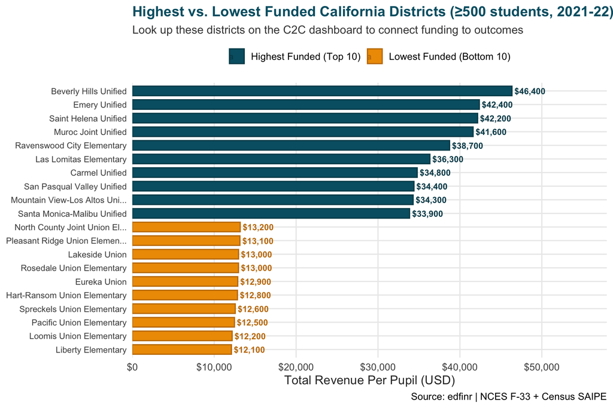

```r
# Create a "spotlight" visualization: top 10 and bottom 10 districts by per-pupil revenue
# in California, labeled for easy C2C lookup

ca_spotlight <- ca_key |>
  filter(enroll >= 500,
         !is.na(rev_total_pp),
         !is.na(dist_name)) |>
  arrange(rev_total_pp) |>
  slice(c(1:10, (n()-9):n())) |>
  mutate(
    group = ifelse(rev_total_pp <= quantile(ca_key$rev_total_pp[ca_key$enroll >= 500], 0.1, na.rm=TRUE),
                   "Lowest Funded (Bottom 10)", "Highest Funded (Top 10)"),
    lea_name_short = str_trunc(dist_name, 30)
  )

ggplot(ca_spotlight,
       aes(x = reorder(lea_name_short, rev_total_pp),
           y = rev_total_pp,
           fill = group,
           color = group)) +
  geom_col(width = 0.7) +
  geom_text(aes(label = dollar(rev_total_pp, scale = 1, accuracy = 100)),
            hjust = -0.08,
            size = 3.2,
            fontface = "bold") +
  coord_flip() +
  scale_y_continuous(labels = dollar_format(scale = 1),
                     expand = expansion(mult = c(0, 0.25))) +
  scale_fill_manual(values  = c("Lowest Funded (Bottom 10)" = "#EE9B00", "Highest Funded (Top 10)" = "#005F73")) +
  scale_color_manual(values = c("Lowest Funded (Bottom 10)" = "#C47A00", "Highest Funded (Top 10)" = "#004A59")) +
  labs(
    title    = "Highest vs. Lowest Funded California Districts (≥500 students, 2021-22)",
    subtitle = "Look up these districts on the C2C dashboard to connect funding to outcomes",
    x        = NULL,
    y        = "Total Revenue Per Pupil (USD)",
    fill     = NULL, color = NULL,
    caption  = "Source: edfinr | NCES F-33 + Census SAIPE"
  ) +
  theme(legend.position = "top",
        axis.text.y = element_text(size = 9))
```

**Checkpoint C.2 — Integration Challenge:**

Choose **one district** from the plot above and look it up on the C2C Student Pathways Dashboard.

1. What do the student outcome metrics (graduation rate, college enrollment, etc.) look like for this district?
2. Does the funding level seem to predict the outcomes you see?
3. Are any student subgroups **suppressed** in the dashboard data for this district? If so, which ones?
4. Using the C2C student story blog as a reference: how would you describe the **strengths** of students in this community, rather than only the challenges?

```r
# YOUR ANSWER HERE — District chosen: ___________
# 1.
# 2.
# 3.
# 4.
```

# 4 Exit Ticket

**Complete all four questions below.** This is your exit ticket — submit as a knitted HTML document or print your answers as comments in the code chunks below.

```r
# EXIT TICKET QUESTION 1: Research Question
#
# Write ONE specific, measurable, data-driven research question about K-12
# education equity. Name the specific variables and population.
#
# Example: "Does per-pupil instructional spending (from edfinr's full dataset)
# predict higher 4-year graduation rates in high-poverty California districts
# on the C2C Student Pathways Dashboard?"
#
# YOUR RESEARCH QUESTION:
#
```

```r
# EXIT TICKET QUESTION 2: Variables
#
# List:
#   (a) Two edfinr variables you would use to answer your research question
#   (b) One C2C dashboard filter you would apply
#
# (a) edfinr variables:
#       1.
#       2.
#
# (b) C2C dashboard filter:
#       1.
#
```

```r
# EXIT TICKET QUESTION 3: Data Suppression
#
# In 2-3 sentences:
#   - Define data suppression as used in the C2C dashboard
#   - Explain the N ≤ 10 rule and why it exists
#   - Describe how suppression could affect YOUR research question above
#
# YOUR ANSWER:
#
```

```r
# EXIT TICKET QUESTION 4: Reflection on Representation
#
# In ONE sentence: Name a community that is likely underrepresented
# in education finance data because of suppression or data gaps,
# and explain why their visibility in data matters.
#
# YOUR ANSWER:
#
```

# 5 Going Further (Optional Extensions)

Interest peaked? Try these extensions to dig deeper into the data.

## 5.1 Try the `full` Dataset

The full `edfinr` dataset has 89 variables including detailed expenditure breakdowns. Try loading it:

```r
# Full dataset for California — more variables, slightly slower download
ca_full <- get_finance_data(
  yr           = "2022",
  geo          = "CA",
  dataset_type = "full"
)

# Explore additional expenditure variables
ca_full |>
  select(dist_name, enroll,
         exp_instr_total,      # Total instructional spending
         exp_tech_equip,       # Technology equipment
         exp_supp_stu_total,   # Student support services
         exp_emp_salary,       # Employee salaries
         stpov_pct) |>
  arrange(desc(exp_instr_total)) |>
  head(20)
```

## 5.2 Explore a Regional Comparison

```r
# Compare a region of states — useful for policy comparisons
midwest <- get_finance_data(
  yr  = "2022",
  geo = "IL,IN,OH,MI,WI",
  dataset_type = "skinny"
)

# What is the funding gap in each state?
midwest |>
  filter(!is.na(rev_total_pp),
         !is.na(stpov_pct)) |>
  group_by(state) |>
  summarize(
    median_rev_pp          = median(rev_total_pp, na.rm = TRUE),
    rev_pp_high_pov_median = median(rev_total_pp[stpov_pct > median(stpov_pct, na.rm=TRUE)], na.rm=TRUE),
    rev_pp_low_pov_median  = median(rev_total_pp[stpov_pct <= median(stpov_pct, na.rm=TRUE)], na.rm=TRUE),
    funding_gap            = rev_pp_low_pov_median - rev_pp_high_pov_median
  )
```

## 5.3 Download the C2C Data and Explore

```r
# Download the "How much do students earn after they graduate?"
# file from https://c2c.ca.gov/query-builder-student-pathways-dataset/

# Load the file
c2c <- read_csv("wage_award_data_details.csv",
                show_col_types = F)

# Skipped but recommended to skim
# skim(c2c)

# Filter to the All Demographics category and
# get individual district data for join
c2c <- c2c |>
  filter(DEMO_CATEGORY == 'All',
         DISTRICT_TYPE != 'All') |>
  # Adjust year variable for joining
  mutate(year = str_extract(ACADEMIC_YEAR, "^\\d{4}"))

# Join the data by district and year
combined_data <- ca_multi |>
  mutate(DISTRICT_CODE = str_extract(state_leaid, "(?<=-).*")) |>
  left_join(c2c,
            by = join_by(DISTRICT_CODE, year)) |>
  filter(WAGE_YEAR1 > 0)

# Visualize Trend
combined_data |>
  group_by(AWARD_CATEGORY, year) |>
  summarize(mean_WAGE_YEAR1 = mean(WAGE_YEAR1),
            .groups = 'drop') |>
  ggplot(aes(x = year,
             y = mean_WAGE_YEAR1,
             color = AWARD_CATEGORY,
             group = AWARD_CATEGORY)) +
  geom_point() +
  geom_line() +
  scale_color_manual(values = c(
    "Bachelor's Degree - Did Not Transfer" = "#005F73",
    "Bachelor's Degree - Transferred" = "#0A9396",
    "Associate Degree" = "#94D2BD",
    "Community College Certificate" = "#EE9B00")) +
  scale_y_continuous(labels = dollar_format(scale = 1)) +
  labs(
    title    = "Average Starting Wage Trend, California (2018–2022, 2022 Dollars)",
    subtitle = "Students split by award type in their graduation year",
    x        = "Graduation Year",
    y        = "Mean Year 1 Wage (2022 USD)",
    color    = NULL,
    caption  = "Source: California C2c, edfinr | CPI-adjusted using CPI-U"
  ) +
  theme(legend.position = "top") +
  guides(color = guide_legend(nrow = 2))
```

**You’ve completed the Funding Futures notebook!**

You’ve used real federal data to investigate one of the most persistent inequities in American education: the connection between where a child grows up and the resources their school receives.

The `edfinr` package makes this kind of analysis accessible to everyone — not just professional researchers. The C2C dashboard makes the human consequences of these funding patterns visible and the data release allows us to deeply examine patterns of inequality.

What will you do with what you’ve learned?

*Data sources: NCES F-33 Survey, U.S. Census Bureau SAIPE, American Community Survey (ACS) via the `edfinr` package. C2C Student Pathways Dashboard: https://databydesign.caschooldashboard.org/*